# DataAn3_SalgaB

## Introduction

The main goal of the analysis is to build a firm success prediction model for people in investment decisions. The reason for this is to invest in quickly growing companies, since the investor is able to earn more. I built a fast growth prediction model on mid-sized European country’s firms’ data. The data is used from https://osf.io/b2ft9/. In the dataset, there are all registered companies from 2005 to 2016 in three industries. These industries are auto manufacturing, equipment manufacturing, hotels, and restaurants. The scope of the project is to build a model, which can predict whether a company will be successful or not in the next few years. I consider a company successful if its sales grew more than 30% of CAGR (Compound Annual Growth Rate). The growth of CAGR is calculated as the average annual rate of sales growth between 2012 and 2013. In the analysis, I viewed 7 different prediction models: OLS, LASSO, and Random Forest. The best model was selected based on the best AUC, RMSE, and the average expected loss.

## Data Cleaning

The Bisnode dataset includes detailed information about companies from middle-sized countries in Europa. The raw data contains registered companies between 2005 and 2016 in three industries(auto manufacturing, equipment manufacturing, hotels, and restaurants). The data preparation started with 287 829 observations and 48 variables. The raw data has information as balance sheet, properties of the company, profit and loss elements. First, I dropped those observations with too many NA values. For the analysis, many variables were created, like CAGR, which shows the success of the companies. I consider a company successful and fast-growing if its CAGR is 30% or more on year on year basis. Next to CAGR, the logarithmic form of sales is created. The analysis focused on the period 2012-2013, so I filtered the dataset on the selected period. The dataset was filtered for companies with full balance sheets and with valid sales data. At the end of the data cleaning, the data set was 13 846 observations and 114 variables. I also checked the financial variables and their validity. I also created category variables and created factors. After data preparation finished, the next task was to separate variables. In the end, I separated the models into nine different groups: The first group is Raw variables. It contains key variables for prediction like profit, loss, and balance sheet. The next three groups are Engine variable 1-2-3. These groups contain profit and loss, balance sheet elements along, the squared form of some key variables along with some flags variables. The D1 group has variables measuring the change of sales. The HR group has variables age, CEO gender, and average labor number. The Firm group has the age of the company, region, and others. The last two groups are Interaction 1 and 2. Those contain interactions of variables.

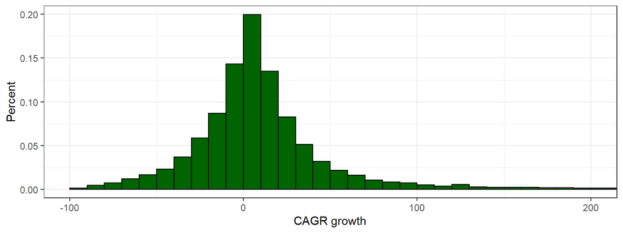

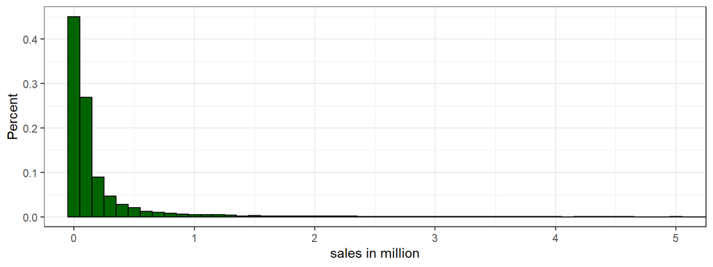

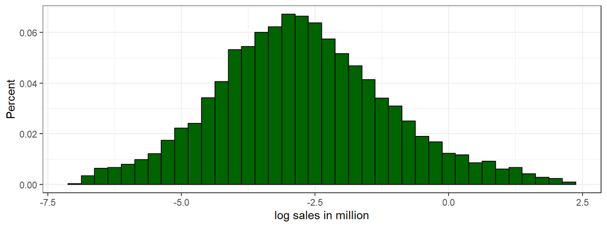

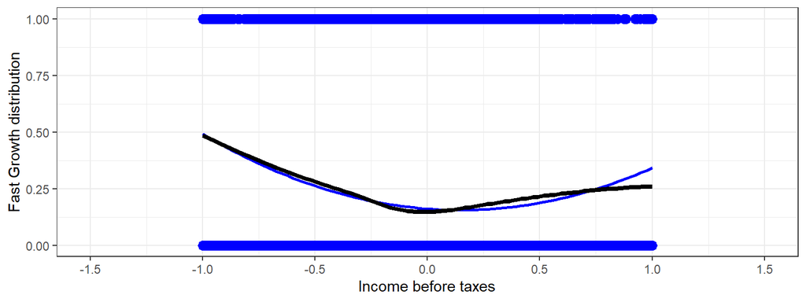

# Modelling

The analysis aims to predict the fast growth of companies. To be able to predict the yearly CAGR calculated between 2012 and 2013 for each company. The threshold was set for a 30% increase in CAGR, and only those firms who reach it are considered fast-growing companies. If the analysis would consider only 1 year of CAGR, that would be a too short period to help the prediction. However, the prediction aims to analyze the firms for the 2 years only. Before the model building and training, the dataset was divided into a train and a holdout set. The holdout dataset contains 20% of the observation, which was randomly selected and the left of the values went into the training dataset. The holdout dataset is used to evaluate the performance of the last model by simulating the use of its unknown, live data. The training dataset is not good for this purpose, since, for each of the models, 5-fold cross-validation was built, sot the dataset was divided 5 times to train and test sets.

### I. model: 5 Logit models

The analysis started with five different logit models for predicting. The built models have different variables with increasing complexity. The first two models have arbitrarily chosen variables, which were mainly sales, profit-loss, and industry category of the firms. The following models have more and more features than the first two models. The model comparison is based on two measures: the Root Mean Squared Error (RMSE) and the Area Under Curve (AUC). The measures averaged on the five different folds used during cross-validation. the results table shows the RMSE and AUC values are not very different for the five models. The best model is the fourth model (X4) since it has the lowest RMSE, and also this model has the highest AUC. So, the fourth model outperformed all the others based on RMSE and AUC. The X4 model is used as a benchmark, however, it is a quite complex model. The complexity comes from having all the financial variables, firm-specific details, some features of the growth of sales, and some variables about the CEO.

### II. model: LASSO

The five Logit models were followed in the analysis LASSO to find the model which contains the most important variables. This model is based on calculation and not manually set up like the logit models. LASSO uses the same variables as the fifth logit model did, but it uses interactions as well. The best LASSO model is compared under the same RMSE and AUC measurements. The best model has only a slightly better RMSE, but the AUC value by the fourth logit model is superior.

### III. model: Random forest

The LASSO model was followed by Random Forest since maybe it has better prediction power. The reason for checking random forest is since the random forest is better at finding non-linear patterns and interactions. This model contains similar variables like the best logit model the fourth one. The tune grid for the random forest was set up to grow 500 trees with 10 and 15 observations at each node and 5-7 variables at each split. The Random forest outperforms every other model in terms of RMSE and AUC as well. The RMSR is 0.3673 and AUC is 0.7146.

### ROC curve

```
##       Number.of.predictors   CV.RMSE    CV.AUC
## LASSO                  115 0.3684327 0.6885580
## X1                      11 0.3760091 0.6667622
## X2                      18 0.3695974 0.6985763
## X3                      35 0.3692694 0.7037555
## X4                      82 0.3690659 0.7072855
## X5                     156 0.3701734 0.7020541
```

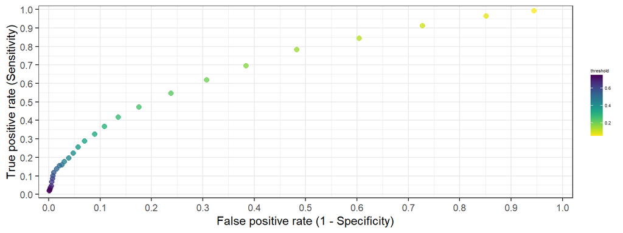

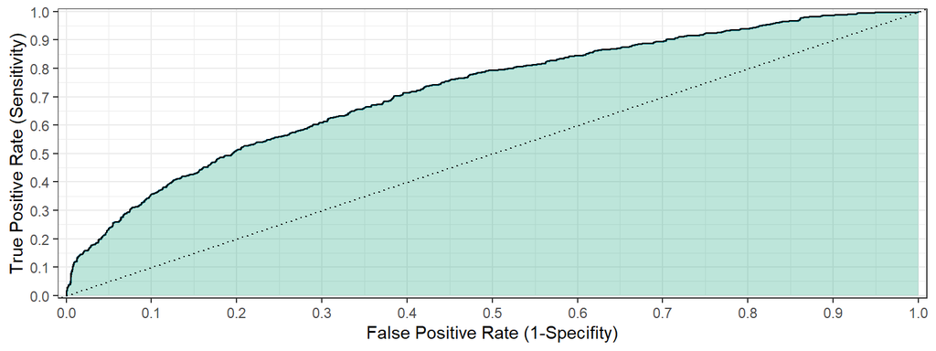

```
## no_fast_growth    fast_growth
##           2635            134
```

```
##                 Reference
## Prediction       no_fast_growth fast_growth
##   no_fast_growth           2158         477
##   fast_growth                46          88
```

```
## [1] 0.1966961
```

```
##                 Reference
## Prediction       no_fast_growth fast_growth
##   no_fast_growth           1512         210
##   fast_growth               692         355
```

### Finding optimal threshold

For finding the optimal threshold value, a loss function was set up for the problem of the analysis. The analysis contains some interesting details. So, the analysis aims to predict the fast growth of firms, but in case of a False-negative error, the situation is worse than normal, since the investor loses a good opportunity to invest, because that company will grow significantly in the next years. However, in the case of a False positive error, the analysis advises a firm to invest money in, but the company is not a fast-growing firm. The investor will not lose any money probably, only his/her money will increase slower. In the analysis is key to index the high cost of a False-negative error, so its cost was set 3 times more as a False positive error. With this set up the analysis could come up with the best threshold that minimizes the expected loss. The formula for the optimal threshold would be 1/(3+1)=0.25. This is a good benchmark for the calculation. The optimal threshold selection algorithm was run on the train data using the 5-fold cross-validation. The model with the lowest RMSE and lowest expected loss is the Random forest model. It has the optimal threshold of 0.282. Both the formula and the algorithm have similar results.

### Model choice

```
## [1] 0.4871795
```

```
##                 Reference
## Prediction       no_fast_growth fast_growth
##   no_fast_growth           1887         344
##   fast_growth               317         221
```

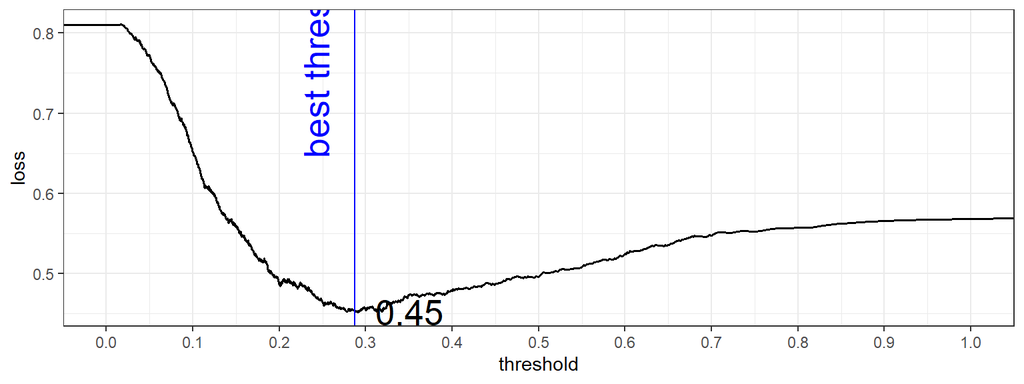

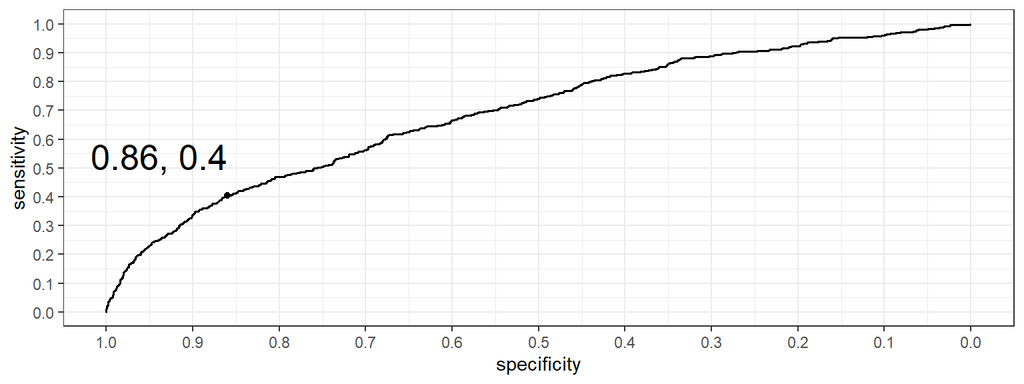

```
## [1] 0.3773635
```

```
## [1] 0.7208085
```

```
## [1] 0.4637053
```

```
##                 Reference
## Prediction       no_fast_growth fast_growth
##   no_fast_growth           1925         335
##   fast_growth               279         230
```

[output not shown]

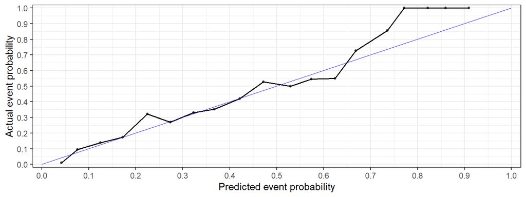

# Summary

|  | no_fast_growth | fast_growth |
| --- | --- | --- |
| no_fast_growth | 1887 | 344 |
| fast_growth | 317 | 221 |